# M1 Midterm I

Data Visualization (STAT 302)

Martha Eichlersmith

2020-05-17

## Datasets

We will need the instructor provided `stephen_curry_shotdata_2014_15.txt` dataset and the `nbahalfcourt.jpg`. The variables should be fairly straightforward after some inspection of the dataset, but we have provided a description of variables just in case.

- `GAME_ID` - Unique ID for each game during the season
- `PLAYER_ID` - Unique player ID
- `PLAYER_NAME` - Player’s name
- `TEAM_ID` - Unique team ID
- `TEAM_NAME` - Team name
- `PERIOD` - Quarter or period of the game
- `MINUTES_REMAINING` - Minutes remaining in quarter/period
- `SECONDS_REMAINING` - Seconds remaining in quarter/period
- `EVENT_TYPE` - `Missed Shot` or `Made Shot`
- `SHOT_DISTANCE` - Shot distance in feet
- `LOC_X` - X location of shot attempt according to tracking system
- `LOC_Y` - Y location of shot attempt according to tracking system

```r
# Load package(s)
library(tidyverse)
library(hexbin)

# Read in the dataset(s)
shots <- read_delim(file = "data/stephen_curry_shotdata_2014_15.txt", delim = "|") %>%
  janitor::clean_names()
```

## Exercises

### Exercise 1

After replicating the plots provide a summary of what the graphics indicate about Stephen Curry’s shot selection (i.e. distance from hoop) and shot make/miss rate and how they relate/compare across distance and game time (i.e. across quarters/periods).

#### Plot 1

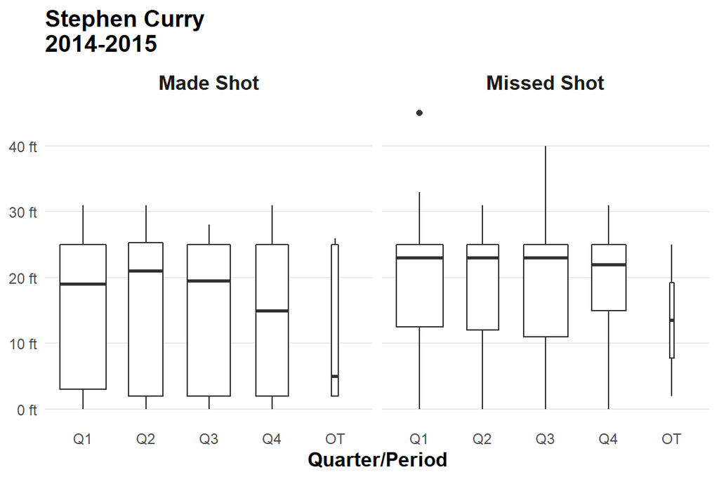

```r
m1_ex1_p1 <- ggplot(shots, aes(as.factor(period), shot_distance)) +
  geom_boxplot(varwidth = TRUE) +
  facet_wrap( ~ event_type) +
  scale_x_discrete(
      name = "Quarter/Period"
    , labels = c("Q1", "Q2", "Q3", "Q4", "OT")
  ) +
  scale_y_continuous(
      name = NULL
    , labels = scales::unit_format(unit = "ft")
    , limits = c(0, NA)
    , breaks = seq(0, 40, 10)
    , minor_breaks = NULL
  ) +
  ggtitle("Stephen Curry\n2014-2015") +
  theme_minimal() +
  theme(
      plot.title = element_text(face = "bold", size = 14)
    , strip.text = element_text(face = "bold", size = 12)
    , axis.title.x = element_text(face = "bold", size = 12)
    , panel.grid.major.x = element_blank()

  )

m1_ex1_p1
```

Unsurprisingly, there are the fewest shots during OT for both missed and made- which makes sense since not every game has an OT period. For all periods, the made shots for each quarter each have a longer IQR and lower median than the missed shots. The difference in the medians makes sense: larger distances make scoring points more difficult so shots made have a shorter distance that shots missed. In addition, there seems to be some variety between the medians by quarter for made shot (Q2 is the highest, where Q4 is significantly lower and a huge drop-off in OT); compared to missed shots where each of the regular periods (Q1, Q2, Q3, Q4) have roughly the same median and OT is the only one noticeably different. There also seems to be slightly less shots taken in the Q2 and Q4 than in Q1 and Q3 (both for shots made and shots missed) which may be do to playing time (some fancy baseball knowledge I don’t know).

#### Plot 2

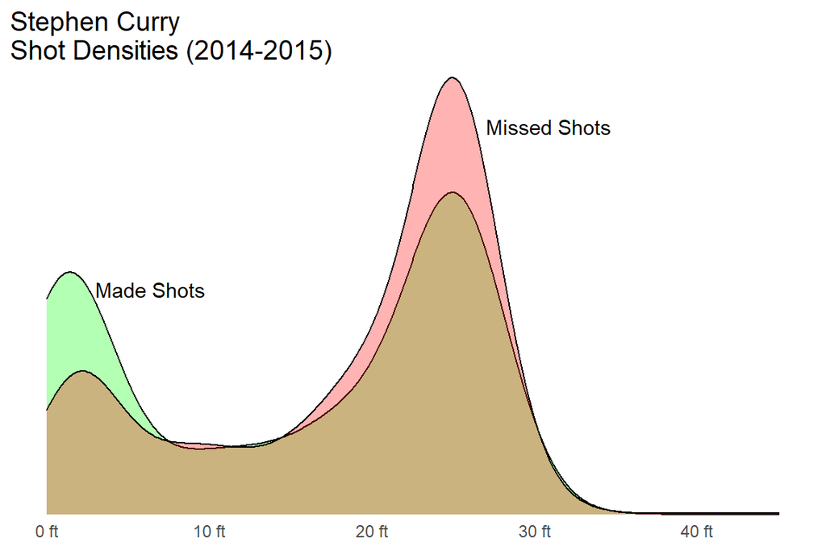

```r
ggplot(shots, aes(shot_distance, fill = event_type)) +
  geom_density(alpha = 0.3) +
  scale_fill_manual(values = c("green", "red")) +
  scale_x_continuous(
      name = NULL
    , breaks = seq(0, 40, 10)
    , minor_breaks = NULL
    , labels = scales::unit_format(unit = "ft")
  ) +
  scale_y_continuous(
      name = NULL
    , breaks = NULL
    , limits = c(0, 0.081)
    , expand = c(0, 0)) +
  annotate(
      "text"
    , x = 3
    , y = 0.04
    , label  = "Made Shots"
    , hjust = 0
    , vjust = 0
  ) +
  annotate(
      "text"
    , x = 27
    , y = 0.07
    , label  = "Missed Shots"
    , hjust = 0
    , vjust = 0
  ) +
  ggtitle("Stephen Curry\nShot Densities (2014-2015)") +
  theme_minimal() +
  theme(
      plot.title = element_text(size = 14)
    , legend.position = "none"
    , panel.grid.major.x = element_blank()
  )
```

### Exercise 2

After examining the two graphics, what do you conclude about Stephen Curry’s shot selection (i.e. distance form hoop) for the 2014-2015 season? Out of the four graphics (two from Exercise 1 and two from Exercise 2), which graphic(s) do you find the most useful when trying to understand Stephen Curry’s shot selection? If you find them all useful, explain what information is better communicated in each.

```r
# picture of half a basketball court to show the location of shots
court <- grid::rasterGrob(jpeg::readJPEG(source = "img/nbahalfcourt.jpg"),
  width = unit(1, "npc"), height = unit(1, "npc")
)


#create base plot with court as background
basecourt <- ggplot() +
  #insert half-court to be used as plot background
  annotation_custom(
    grob = court,
    xmin = -250, xmax = 250,
    ymin = -52, ymax = 418
  ) +
  coord_fixed() +
  xlim(250, -250) +
  ylim(-52, 418)
```

#### Plot 1

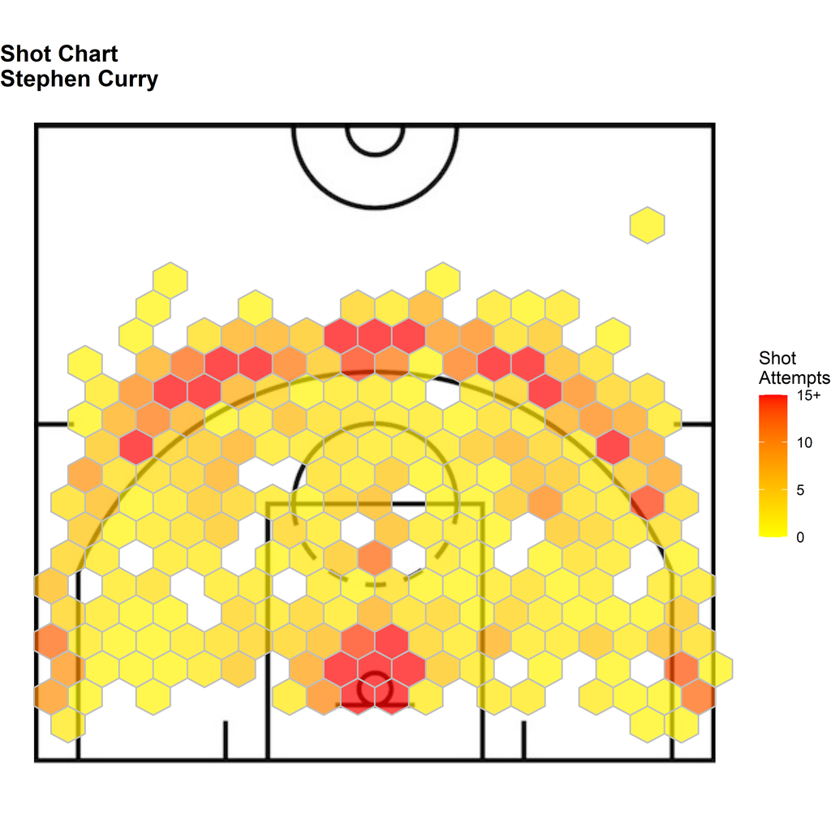

```r
m1_ex2_p1 <-  basecourt +
  geom_hex(
      data = shots
    , aes(loc_x, loc_y)
    , bins = 20
    , alpha = 0.7
    , color = "grey"
  ) +
  scale_fill_gradient(
      name = "Shot\nAttempts"
    , low = "yellow"
    , high = "red"
    , breaks = c(0, 5, 10, 15)
    , labels = c(0, 5, 10, "15+")
    #set limit of shots to 0 to 15
    , limits = c(0, 15)
    # any shots above 15 will be 'na' so set color to high value = red
    , na.value = "red"
    ) +
  ggtitle("Shot Chart\nStephen Curry") +
  theme_void() +
  theme(plot.title = element_text(face = "bold", size = 14))

m1_ex2_p1
```

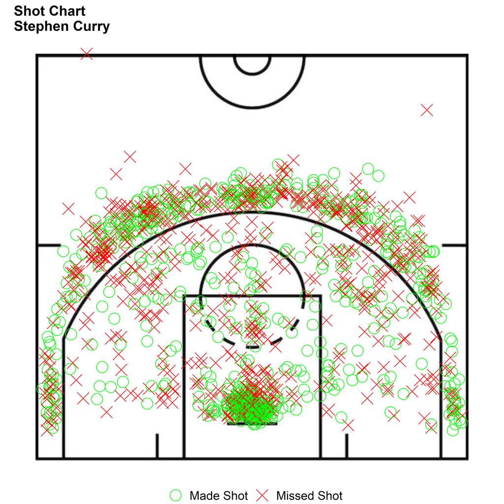

```r
m1_ex2_p2 <- basecourt +
  geom_point(
      data = shots
    , aes(loc_x, loc_y, shape = event_type, color = event_type)
    , fill = NA
    , size = 5
  ) +
  scale_color_manual(
      name = NULL
    , values = c("green", "red")
  ) +
  scale_shape_manual(
      name = NULL
    , values = c(1, 4)
  ) +
  ggtitle("Shot Chart\nStephen Curry") +
  theme_void() +
  theme(
      plot.title = element_text(face = "bold", size = 14)
    , legend.position = "bottom"
    , legend.text = element_text(size = 12)
    )

m1_ex2_p2
```

To understand Curry’s shot selection, the hex map is better as it shows the density of where he take shots. The point chart gives the same idea (more shots around the hoop and outside the 3pt line), but it is difficult to tell the difference in density because there are so many points - definitely a case of over-plotting The idea of looking at the location of the made and missed shots is interesting and I think it would be better to view a faceted hex map to compare shot density between made and missed shots. The results mirror the info from above; there is a higher density of missed shots outside the 3pt line compared to made shots and a higher density of made shots around the hoop compared to missed shots.

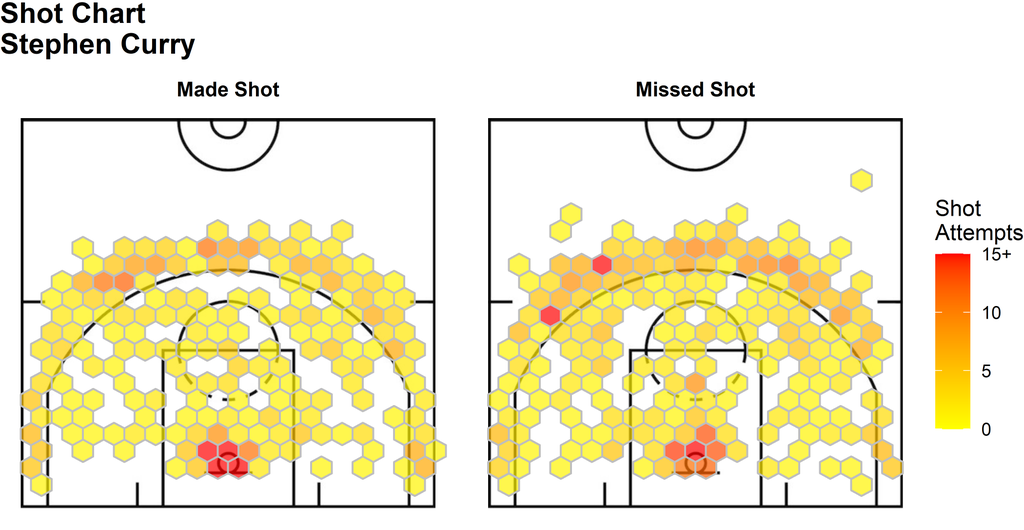

```r
m1_ex2_p1 +
  facet_wrap(~ event_type) +
  theme(
      plot.title = element_text(face = "bold", size = 14, margin = margin(0, 0, 10, 0))
    , strip.text = element_text(face = "bold", size = 10)
  )
```

### Exercise 3

##### Part 1

In 3-5 sentences, describe the core concept/idea and structure of the `ggplot2` package.

`ggplot2` is a data visualization tool that is more powerful and versatile than base R plots. `ggplot2` allows the user to break down the plot into individual components that can be added, removed, or edited. `ggplot2` is based on the Grammar of Graphics; which uses scales and layers to build a plot in a systematic fashion.

##### Part 2

Describe each of the following:

1. `ggplot()`: creates a new plot; this plot is blank without any other specifications
2. `aes()`: maps data to visual aesthetics
3. `geoms`: specifies the type of geometric object to visualize (i.e. points, bars, etc.)
4. `stats`: statistical transformation on the data rather than visualizing the data
5. `scales`: translation of data to visual properties
6. `theme()`: visual appearances that are not related to the data (i.e. background, legend position, title size, etc.)

##### Part 3

Explain the difference between using this code `geom_point(aes(color = VARIABLE))` as opposed to using `geom_point(color = VARIABLE)`.

`geom_point(aes(color = VARIABLE))`: This maps data to color based on value(s) of `VARIABLE`, e.g. if there are three levels of `VARIABLE`, the data will be mapped to three different color based on the level. This option also automatically creates a legend to show which color is assigned to which level(s) of `VARIABLE`.

`geom_point(color = VARIABLE)`: This makes all points one color called `VARIABLE`. No legend is created because there is no mapping from data to aesthetics.